# FIFA 2019 - randomForest for Classification & for Regression

Sau Kha

8/24/2020

# Dataset Introduction

# Load library

```r
# load library
library(utils)
library(randomForest)
library(ggplot2)
library(stats)
library(tidyverse)
library(caTools)
library(dplyr)
library(caret)
library(e1071)
library(randomForestExplainer)
library(nnet)
```

# Introduction

A soccer player typically keeps up his training on skills set that are specific to his position. And conversely, a player’s position is typically placed according how well his skills rated for the position. Additionally, some positions are placed in similar strategic locations in a team formation to play similar roles and will require similar set of skills. For example, LDM, CDM and RDM all are defensive midfielders. LW and RW are wings on the right and right side of the fore field, while LM, CM and RM are midfielders who stay in the middle of the team formation. Further, attacking midfielders (LAM, CAM and RAM) and forwards/strikers (LF, CF, RF and ST) together form the offense team in the fore field, etc.

There are different possible ways of grouping the skills. Attacking skills are important to offense positions, like forwards and strikers while defending skills are crucial to defenders positions. The following shows possible groupings of player skills:

- *Attacking*: Crossing, Finishing, Heading Accuracy, Short Passing, Volleys
- *Skill*: Dribbling, Curve, FK Accuracy, Long Passing, Ball Control
- *Movement*: Acceleration, Sprint Speed, Agility, Reactions, Balance
- *Power*: Shot Power, Jumping, Stamina, Strength, Long Shots
- *Mentality*: Aggression, Interceptions, Positioning, Vision, Penalties, Composure
- *Defending*: Marking, Standing Tackle, Sliding Tackle
- *Goalkeeping*: GK Diving, GK Handling, GK Kicking, GK Positioning, GK Reflexes

I’d like to explore the data set and see how player’s various skill ratings may be used as predictors for player’s Position, Overall Ratings and International Reputation Ranking. Player’s position and international reputation ranking are categorical while overall rating is numeric data. randomForest and Multinomial Logistic Regression algorithms are explored to train prediction models and evaluated for accuracy and effectiveness.

# Part I - randomForest for Classification & for Regression

# Data Exploration

From prior data exploration and visualization of player’s skill ratings data, goalkeepers forms a very distinct cluster from the remaining players. Basic data exploration and Principal Component Analysis (PCA) has been done on predicting Goalkeepers Overall ratings based on skill ratings. For this study, the focus is on the non-goalkeeper cluster. Observations with missing entries in all the position ratings columns were removed, resulting in removing 2085 observations, including all 2025 records of goalkeepers. (Goakeepers are not rated for other positions.)

```r
# Import the data and look at the first six rows
df <- read.csv(file = 'data.csv', dec = "+")
# take a peek at first 5 rows of data
head(df)
```

```
##   ï..     ID              Name Age
## 1   0 158023          L. Messi  31
## 2   1  20801 Cristiano Ronaldo  33
## 3   2 190871         Neymar Jr  26
## 4   3 193080            De Gea  27
## 5   4 192985      K. De Bruyne  27
## 6   5 183277         E. Hazard  27
##                                            Photo Nationality
## 1 https://cdn.sofifa.org/players/4/19/158023.png   Argentina
## 2  https://cdn.sofifa.org/players/4/19/20801.png    Portugal
## 3 https://cdn.sofifa.org/players/4/19/190871.png      Brazil
## 4 https://cdn.sofifa.org/players/4/19/193080.png       Spain
## 5 https://cdn.sofifa.org/players/4/19/192985.png     Belgium
## 6 https://cdn.sofifa.org/players/4/19/183277.png     Belgium
##                                  Flag Overall Potential                Club
```

[output cut: 83 more lines]

```r
# number of goalkeepers - goalkeepers whose ratings for various positions are missing
nrow(df[df$Position == "GK", ])
```

```
## [1] 2025
```

```r
# number of non-goalkeepers whose ratings for various positions are missing
nrow(df[df$LAM == "NA", ])
```

```
## [1] 2085
```

```r
# remove data with missing entries
df <- na.omit(df)
# summary of cleaned data
summary.data.frame(df)
```

```
##       ï..              ID             Name                Age
##  Min.   :    0   Min.   :    16   Length:16122       Min.   :16.00
##  1st Qu.: 4430   1st Qu.:200917   Class :character   1st Qu.:21.00
##  Median : 8870   Median :222028   Mode  :character   Median :25.00
##  Mean   : 8933   Mean   :215084                      Mean   :25.01
##  3rd Qu.:13408   3rd Qu.:236638                      3rd Qu.:28.00
##  Max.   :18206   Max.   :246620                      Max.   :41.00
##     Photo           Nationality            Flag              Overall
##  Length:16122       Length:16122       Length:16122       Min.   :46.00
##  Class :character   Class :character   Class :character   1st Qu.:62.00
##  Mode  :character   Mode  :character   Mode  :character   Median :66.00
##                                                           Mean   :66.46
##                                                           3rd Qu.:71.00
##                                                           Max.   :94.00
##    Potential         Club            Club.Logo            Value
##  Min.   :48.00   Length:16122       Length:16122       Length:16122
##  1st Qu.:67.00   Class :character   Class :character   Class :character
##  Median :71.00   Mode  :character   Mode  :character   Mode  :character
##  Mean   :71.52
##  3rd Qu.:75.00
##  Max.   :95.00
##      Wage              Special     Preferred.Foot     International.Reputation
##  Length:16122       Min.   :1000   Length:16122       Min.   :1.000
##  Class :character   1st Qu.:1526   Class :character   1st Qu.:1.000
##  Mode  :character   Median :1670   Mode  :character   Median :1.000
##                     Mean   :1667                      Mean   :1.115
##                     3rd Qu.:1806                      3rd Qu.:1.000
##                     Max.   :2346                      Max.   :5.000
##    Weak.Foot      Skill.Moves     Work.Rate          Body.Type
##  Min.   :1.000   Min.   :2.000   Length:16122       Length:16122
##  1st Qu.:3.000   1st Qu.:2.000   Class :character   Class :character
##  Median :3.000   Median :2.000   Mode  :character   Mode  :character
##  Mean   :3.005   Mean   :2.533
##  3rd Qu.:3.000   3rd Qu.:3.000
##  Max.   :5.000   Max.   :5.000
##   Real.Face           Position         Jersey.Number      Joined
##  Length:16122       Length:16122       Min.   : 2.00   Length:16122
##  Class :character   Class :character   1st Qu.: 9.00   Class :character
##  Mode  :character   Mode  :character   Median :17.00   Mode  :character
##                                        Mean   :19.42
```

[output cut: 99 more lines]

```
##  Max.   :96.00   Max.   :94.00   Max.   :93.00   Max.   :91.00   Max.   :37.0
##    GKHandling      GKKicking     GKPositioning     GKReflexes
##  Min.   : 1.00   Min.   : 1.00   Min.   : 1.00   Min.   : 1.00
##  1st Qu.: 8.00   1st Qu.: 8.00   1st Qu.: 8.00   1st Qu.: 8.00
##  Median :11.00   Median :11.00   Median :10.50   Median :10.00
##  Mean   :10.56   Mean   :10.55   Mean   :10.53   Mean   :10.51
##  3rd Qu.:13.00   3rd Qu.:13.00   3rd Qu.:13.00   3rd Qu.:13.00
##  Max.   :33.00   Max.   :41.00   Max.   :33.00   Max.   :37.00
##  Release.Clause
##  Length:16122
##  Class :character
##  Mode  :character
##
##
##
```

```r
# return the column names of the data set
print(colnames(df))
```

```
##  [1] "ï.."                      "ID"
##  [3] "Name"                     "Age"
##  [5] "Photo"                    "Nationality"
##  [7] "Flag"                     "Overall"
##  [9] "Potential"                "Club"
## [11] "Club.Logo"                "Value"
## [13] "Wage"                     "Special"
## [15] "Preferred.Foot"           "International.Reputation"
## [17] "Weak.Foot"                "Skill.Moves"
## [19] "Work.Rate"                "Body.Type"
## [21] "Real.Face"                "Position"
## [23] "Jersey.Number"            "Joined"
## [25] "Loaned.From"              "Contract.Valid.Until"
## [27] "Height"                   "Weight"
## [29] "LS"                       "ST"
```

[output cut: 30 more lines]

```r
colnames(df)[1] <- "ind"
# convert char type to factor
df$International.Reputation <- as.factor(df$International.Reputation)
# ordered factor
df$International.Reputation <- as.ordered(df$International.Reputation)
# convert char to factor
df$Position <- as.factor(df$Position)
# Number of Players by Position
table(df$Position)
```

```
##
##  CAM   CB  CDM   CF   CM  LAM   LB  LCB  LCM  LDM   LF   LM   LS   LW  LWB  RAM
##  958 1778  948   74 1394   21 1322  648  395  243   15 1095  207  381   78   21
##   RB  RCB  RCM  RDM   RF   RM   RS   RW  RWB   ST
## 1291  662  391  248   16 1124  203  370   87 2152
```

```r
# Number of Players by International Reputation Rank
table(df$International.Reputation)
```

```
##
##     1     2     3     4     5
## 14644  1149   279    45     5
```

# Data Visualization

```r
# Player Positions Versus mean Overall Rating
results <- aggregate(Overall ~ Position, data = df, FUN = "mean", simplify = TRUE)
# print results table
print(results)
```

```
##    Position  Overall
## 1       CAM 66.90397
## 2        CB 65.02475
## 3       CDM 66.31329
## 4        CF 65.82432
## 5        CM 63.72956
## 6       LAM 71.85714
## 7        LB 65.85477
## 8       LCB 69.24074
## 9       LCM 69.27089
## 10      LDM 69.03292
## 11       LF 73.86667
## 12       LM 66.69224
## 13       LS 70.06280
## 14       LW 66.61680
## 15      LWB 66.51282
## 16      RAM 72.28571
## 17       RB 66.05887
## 18      RCB 69.28399
## 19      RCM 69.07673
## 20      RDM 69.75403
## 21       RF 73.25000
## 22       RM 66.49644
## 23       RS 69.52217
## 24       RW 66.92973
## 25      RWB 64.65517
## 26       ST 65.53578
```

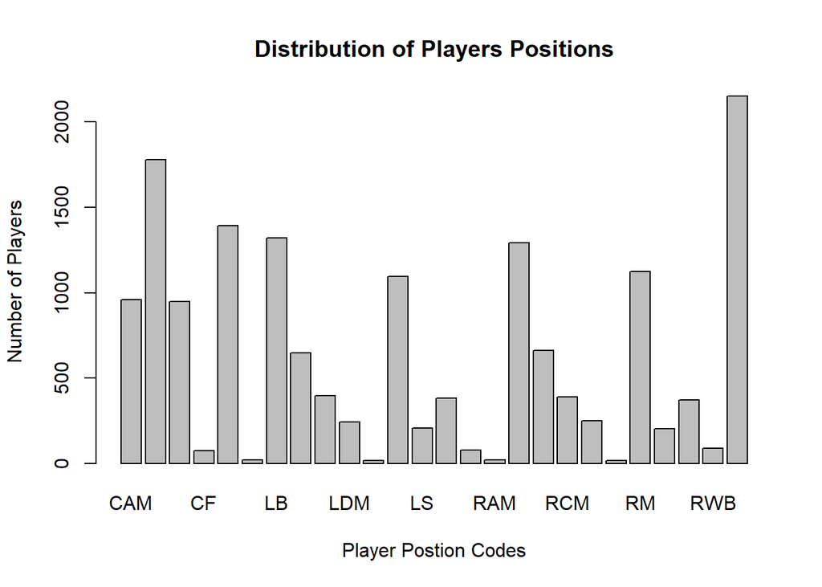

```r
# visualize uneven distribution, "GK" not included
plot(df$Position, main = "Distribution of Players Positions",
     ylab = "Number of Players", xlab = "Player Postion Codes")
```

```r
# International Reputation Ranking
aggregate(df$Overall ~ df$International.Reputation, data = df, FUN = "mean")
```

```
##   df$International.Reputation df$Overall
## 1                           1   65.40078
## 2                           2   75.49869
## 3                           3   81.28315
## 4                           4   86.15556
## 5                           5   91.20000
```

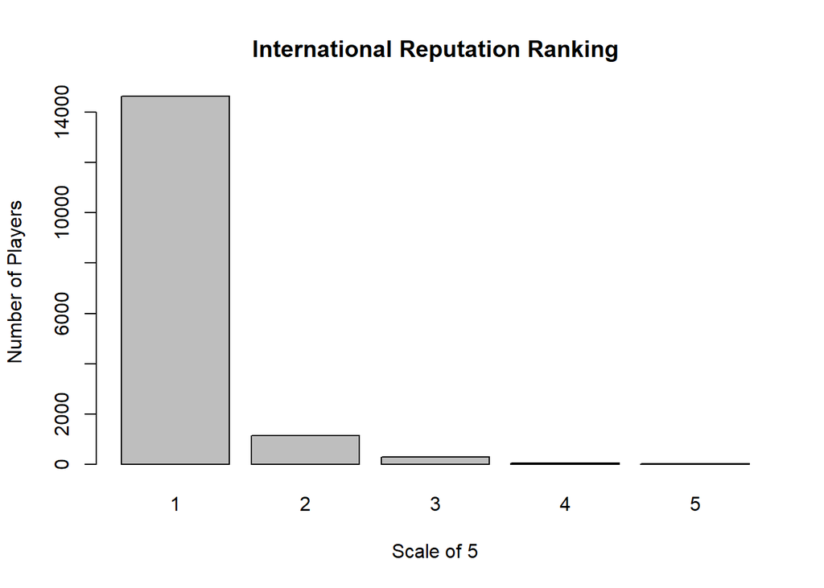

```r
#par(mfrow = c(2,1))
plot(df$International.Reputation, main = "International Reputation Ranking",
     ylab = "Number of Players", xlab = "Scale of 5")
```

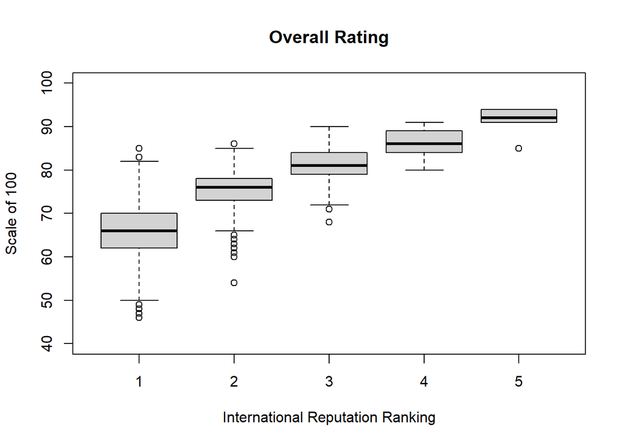

```r
plot( df$Overall ~ df$International.Reputation, main = "Overall Rating",
      xlab = "International Reputation Ranking", ylab = "Scale of 100", ylim = c(40, 100))
```

# Data Preparation

## Data Sampling and Splitting for Machine Learning Model Training and Testing

```r
# sampling only 4000 rows (only use during coding)
df1 = df[sample(nrow(df),  4000, replace = TRUE), ]

# df = complete dataset, df1 = only 4000 rows
# col 8 = Overall, 16 = Int'l Reputation, 22 = Position, 55:88 = skill ratings
df_skills <- df[ , c(8, 16, 22, 55:88)]

# split data, keeping same dist of International Reputation in both subsets

split = sample.split(df_skills$International.Reputation, SplitRatio = 0.8)
train_skills = subset(df_skills, split == TRUE)
test_skills = subset(df_skills, split == FALSE)
rm(split)
```

# A) randomForest: Classification Model for Player’s International Reputation Ranking

```r
rf_IntRep_class <- randomForest(formula = International.Reputation ~ .,
                                data = train_skills[ , c(2, 4:37)], importance = TRUE)
```

## RF Classification Model Metrics - International Reputation

```r
# randomForest results for classification
attributes(rf_IntRep_class)
```

```
## $names
##  [1] "call"            "type"            "predicted"       "err.rate"
##  [5] "confusion"       "votes"           "oob.times"       "classes"
##  [9] "importance"      "importanceSD"    "localImportance" "proximity"
## [13] "ntree"           "mtry"            "forest"          "y"
## [17] "test"            "inbag"           "terms"
##
## $class
## [1] "randomForest.formula" "randomForest"
```

```r
print(rf_IntRep_class)
```

```
##
## Call:
##  randomForest(formula = International.Reputation ~ ., data = train_skills[,      c(2, 4:37)], importance = TRUE)
##                Type of random forest: classification
##                      Number of trees: 500
## No. of variables tried at each split: 5
##
##         OOB estimate of  error rate: 6.94%
## Confusion matrix:
##       1   2  3 4 5 class.error
## 1 11582 130  3 0 0  0.01135297
## 2   555 329 35 0 0  0.64200218
## 3    22 114 85 2 0  0.61883408
## 4     0   7 23 6 0  0.83333333
## 5     0   0  2 2 0  1.00000000
```

```r
# number of players who ranked 5 in whole data set
nrow(df[df$International.Reputation == '5', ])
```

```
## [1] 5
```

```r
# number of players who ranked 5 in test data set
nrow(train_skills[train_skills$International.Reputation == '5', ])
```

```
## [1] 4
```

```r
# display the predictors in the order of importance, contributing to classification
# varImpPlot(rf_IntRep_class, main = "Variable Importance")
```

## Tune Model with Class Weight - Ranger Package

Alternatively, randomForest for classification can be run with class weight when the class distribution is skewed. Ranger is a fast implementation of random forests (Breiman 2001) or recursive partitioning, particularly suited for high dimensional data. Ranger function from Ranger package includes parameters that are particularly useful for this data set: case.weights (for sampling of training observations), class.weights (for outcome classes), split.select.weights (Numeric vector with weights between 0 and 1, representing the probability to select variables for splitting. Alternatively, a list of size num.trees, containing split select weight vectors for each tree can be used), etc. Users may apply special tuning of appropriate parameters to adapt the training for unbalanced classification problem at hand with class weights as shown below.

```r
# Count of players in each of the International Reputation Rank
table(df$International.Reputation)
```

```
##
##     1     2     3     4     5
## 14644  1149   279    45     5
```

```r
# print class weight for each rank
print(table(df$International.Reputation) / sum(table(df$International.Reputation)))
```

```
##
##            1            2            3            4            5
## 0.9083240293 0.0712690733 0.0173055452 0.0027912170 0.0003101352
```

## Prediction Results - International Reputation

The metrics below shows that the overall classification accuracy rate of test data (new players) is 93%, which does not seem bad. The sensitivity for Rank 1 is also high, at above 98%. However, the sensitivity for the remaining ranks are pretty low. Additionally, there is only 1 player who rank 5 in the test data, the sensitivity and specificity are not useful metrics for a 1-person class. Since the usefulness of this classification model is predict players of top rank based on their skill ratings, it does not really serve its purpose.

```r
# predict Int'l Reputation Rank of players in test set
test_IntRep_hat <- predict(rf_IntRep_class, test_skills[ , 4:37], type = "response")

# confusion matrix of test data
c <- confusionMatrix(test_IntRep_hat, test_skills$International.Reputation)
print(c)
```

```
## Confusion Matrix and Statistics
##
##           Reference
## Prediction    1    2    3    4    5
##          1 2892  139    5    0    0
##          2   35   83   34    1    0
##          3    2    8   17    8    0
##          4    0    0    0    0    1
##          5    0    0    0    0    0
##
## Overall Statistics
##
##                Accuracy : 0.9278
##                  95% CI : (0.9183, 0.9365)
##     No Information Rate : 0.9082
##     P-Value [Acc > NIR] : 4.139e-05
##
##                   Kappa : 0.4892
##
##  Mcnemar's Test P-Value : NA
##
## Statistics by Class:
##
##                      Class: 1 Class: 2 Class: 3  Class: 4  Class: 5
## Sensitivity            0.9874  0.36087 0.303571 0.0000000 0.0000000
## Specificity            0.5135  0.97663 0.994320 0.9996891 1.0000000
## Pos Pred Value         0.9526  0.54248 0.485714 0.0000000       NaN
## Neg Pred Value         0.8042  0.95215 0.987774 0.9972084 0.9996899
## Prevalence             0.9082  0.07132 0.017364 0.0027907 0.0003101
## Detection Rate         0.8967  0.02574 0.005271 0.0000000 0.0000000
## Detection Prevalence   0.9414  0.04744 0.010853 0.0003101 0.0000000
## Balanced Accuracy      0.7504  0.66875 0.648946 0.4998445 0.5000000
```

# B) randomForest: Classification Model for Player’s Position

```r
# fit randomForest model for classification
rf_Post_class <- randomForest(formula = Position ~ .,
                                data = train_skills[ , c(3:37)], importance = TRUE)
```

## RF Classification Model Metrics - Player’s Position

```r
# randomForest model metrics for classification
attributes(rf_Post_class)
```

```
## $names
##  [1] "call"            "type"            "predicted"       "err.rate"
##  [5] "confusion"       "votes"           "oob.times"       "classes"
##  [9] "importance"      "importanceSD"    "localImportance" "proximity"
## [13] "ntree"           "mtry"            "forest"          "y"
## [17] "test"            "inbag"           "terms"
##
## $class
## [1] "randomForest.formula" "randomForest"
```

```r
print(rf_Post_class)
```

```
##
## Call:
##  randomForest(formula = Position ~ ., data = train_skills[, c(3:37)],      importance = TRUE)
##                Type of random forest: classification
##                      Number of trees: 500
## No. of variables tried at each split: 5
##
##         OOB estimate of  error rate: 53.69%
## Confusion matrix:
##     CAM   CB CDM CF  CM LAM  LB LCB LCM LDM LF  LM LS LW LWB RAM  RB RCB RCM
## CAM 360    1   7  0 149   0   1   0   0   0  0  86  0  1   0   0   1   0   1
## CB    0 1238  66  0  12   0  44  19   0   0  0   0  0  0   0   0  48  27   0
## CDM   1   85 393  0 198   0  24   3   1   0  0   1  0  0   0   0  33   3   0
## CF   11    0   0  0   1   0   0   0   0   0  0   7  0  0   0   0   0   0   0
## CM   64    3 126  0 827   0  31   0   7   0  0  12  0  0   0   0  15   0   5
## LAM  10    0   0  0   0   0   0   0   0   0  0   2  0  0   0   0   0   0   0
## LB    1   63  25  0  32   0 535   1   0   0  0   4  0  0   0   0 372   1   0
## LCB   0  387  22  0   3   0  24  21   0   0  0   0  0  0   0   0  26  33   0
## LCM  37    7  82  0 153   0   6   0   1   0  0  17  0  0   0   0   8   0   2
## LDM   7   11  72  0  76   0   9   1   2   0  0   1  0  0   0   0   9   2   3
## LF    2    0   0  0   2   0   0   0   0   0  0   3  0  0   0   0   0   0   0
## LM   95    0   2  0  70   0  60   0   1   0  0 240  0  1   0   0  27   0   1
## LS    6    0   0  0   0   0   0   0   0   0  0  14  0  0   0   0   0   0   0
## LW   40    0   0  0  11   0   4   0   0   0  1  87  0  1   0   0   3   0   0
## LWB   0    4   0  0   3   0  25   0   1   0  0   3  0  0   0   0  22   0   0
## RAM   9    0   0  0   1   0   0   0   0   0  0   2  0  0   0   0   0   0   0
## RB    1   91  25  0  34   0 423   0   0   0  0   1  0  0   0   0 442   2   0
## RCB   0  408  26  0   3   0  18  20   0   0  0   0  0  0   0   0  20  36   0
## RCM  29    4  69  0 162   0  14   1   2   1  0   8  0  0   0   0  16   0   2
## RDM   6   17 100  0  63   0   4   0   1   0  0   2  0  0   0   0   7   0   3
## RF    1    0   0  0   0   0   0   0   0   0  0   4  0  1   0   0   0   0   0
## RM  108    1   6  0  83   0  35   0   1   0  0 238  0  1   0   0  33   0   2
## RS    3    0   0  0   2   0   0   0   0   0  0  12  0  0   0   0   1   0   0
## RW   30    0   0  0   5   0   4   0   0   0  0  95  0  2   0   0   4   0   0
## RWB   0    2   4  0   5   0  30   0   0   0  0   0  0  0   0   0  23   0   0
## ST   26    3   0  0  11   0   1   0   0   0  0  39  0  0   0   0   1   0   1
##     RDM RF  RM RS RW RWB   ST class.error
## CAM   0  0  92  0  0   0   64  0.52817824
## CB    1  0   0  0  0   0    0  0.14914089
## CDM   1  0   0  0  0   0    0  0.47106326
```

[output cut: 8 more lines]

```
## LM    0  0 269  0  3   0  111  0.72727273
## LS    0  0   7  0  0   0  143  1.00000000
## LW    0  0  88  0  2   0   69  0.99673203
## LWB   0  0   1  0  0   0    0  1.00000000
## RAM   0  0   2  0  0   0    1  1.00000000
## RB    0  0   7  0  0   0    0  0.56920078
## RCB   0  0   1  0  0   0    1  0.93245779
## RCM   1  0   7  0  0   0    4  0.99375000
## RDM   2  0   2  0  0   0    1  0.99038462
## RF    0  0   3  0  0   0    4  1.00000000
## RM    0  0 270  0  3   0  125  0.70198675
## RS    0  0  12  0  1   0  123  1.00000000
## RW    0  0  94  0  4   0   46  0.98591549
## RWB   0  0   4  0  0   0    0  1.00000000
## ST    0  0  39  1  0   0 1600  0.07084785
```

```r
# display the predictors in the order of importance, contributing to classification
# varImpPlot(rf_Post_class, main = "Skills Importance for Classification")
```

# C) randomForest: Regression Model for Player’s Overall Rating

```r
# randomForest: for regression of Player's Overall Rating
rf_Overall_reg <- randomForest(Overall ~ ., train_skills[ , c(1, 4:37)])
```

The randomForest regression model explains high percent (>96%) of the variance in Overall Rating estimated based on player’s skill ratings, with low mean squared residuals (~1.5).

```r
print(rf_Overall_reg)
```

```
##
## Call:
##  randomForest(formula = Overall ~ ., data = train_skills[, c(1,      4:37)])
##                Type of random forest: regression
##                      Number of trees: 500
## No. of variables tried at each split: 11
##
##           Mean of squared residuals: 1.465298
##                     % Var explained: 96.84
```

```r
attributes(rf_Overall_reg)
```

```
## $names
##  [1] "call"            "type"            "predicted"       "mse"
##  [5] "rsq"             "oob.times"       "importance"      "importanceSD"
##  [9] "localImportance" "proximity"       "ntree"           "mtry"
## [13] "forest"          "coefs"           "y"               "test"
## [17] "inbag"           "terms"
##
## $class
## [1] "randomForest.formula" "randomForest"
```

## Model Tuning - ntree & mtry

The Error Rate Versus ntree chart shows that the error rate does not improve much after ntree = 300. The Out-Of-Bag (OOB) error rate chart and table below show that the error is the lowest when mtry = 5.

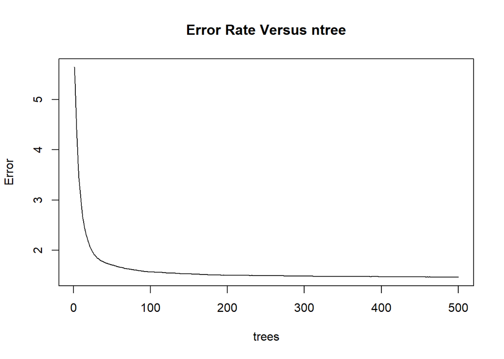

```r
# tune ntree parameter based of error rate: find the optimal value for ntree parameter
plot(rf_Overall_reg, main = "Error Rate Versus ntree") # error rate does not gain much for ntree > 300
```

```
## mtry = 11  OOB error = 1.483845
## Searching left ...
## mtry = 22    OOB error = 1.616982
## -0.0897242 0.001
## Searching right ...
## mtry = 5     OOB error = 1.464467
## 0.01305984 0.001
## mtry = 2     OOB error = 1.811105
## -0.2366996 0.001
```

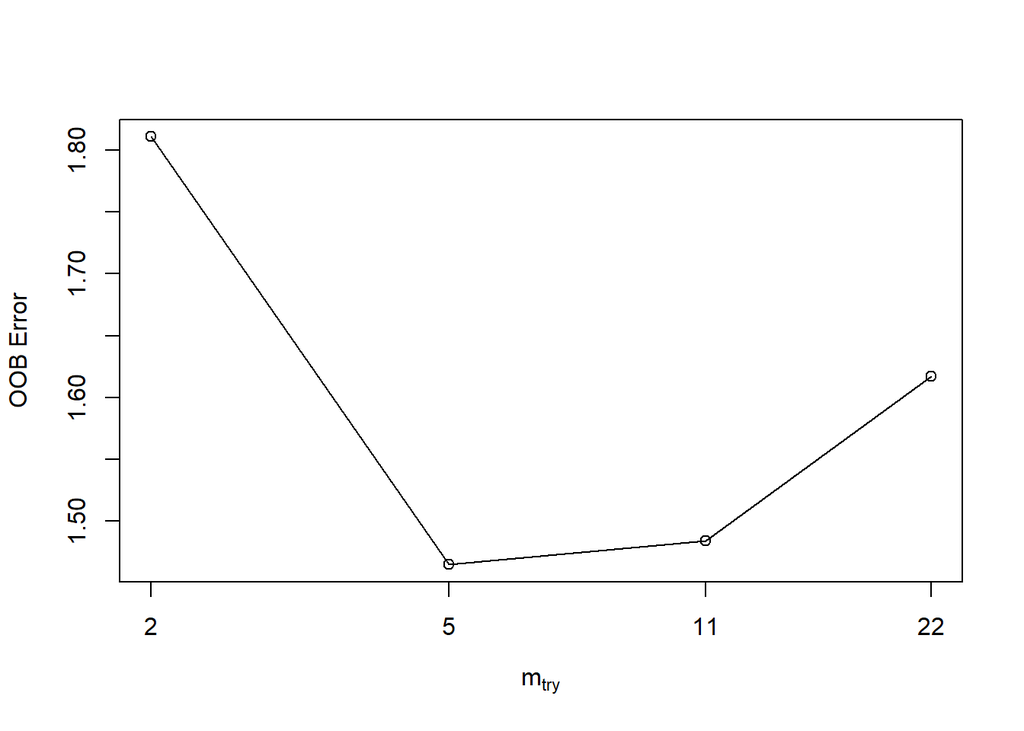

```r
# tune mtry parameter, setting ntree = 300
t <- tuneRF(train_skills[ , 4:37], train_skills[ , 1], stepFactor = 0.5,
            plot = TRUE, ntreeTry = 300, trace = TRUE, improve = 0.001)
```

```r
print(t)
```

```
##    mtry OOBError
## 2     2 1.811105
## 5     5 1.464467
## 11   11 1.483845
## 22   22 1.616982
```

## Re-run RF with fine-tuned ntree and mtry parameters

Here is the regression model from re-running randomForest with the fine-tuned parameters, ntree = 300 and mtry = 5. Comparing the the percent of variance explained and mean of squared residuals to the initial model with 500 trees and 11 variables at each split, this model with 300 trees and 5 variables at each split performs comparatively well. The smaller “forest” requires less storage and computing time, and hence is more efficient.

```r
# re-run randomForest with ntree = 300 & mtry = 5
rf_Overall_reg2 <- randomForest(Overall ~ ., train_skills[ , c(1, 4:37)], importance = TRUE, ntree = 300, mtry = 5, proximity = TRUE)

print(rf_Overall_reg2)
```

```
##
## Call:
##  randomForest(formula = Overall ~ ., data = train_skills[, c(1,      4:37)], importance = TRUE, ntree = 300, mtry = 5, proximity = TRUE)
##                Type of random forest: regression
##                      Number of trees: 300
## No. of variables tried at each split: 5
##
##           Mean of squared residuals: 1.463233
##                     % Var explained: 96.84
```

## RF Regression Model Prediction Results - Player’s Overall Rating

[output not shown]

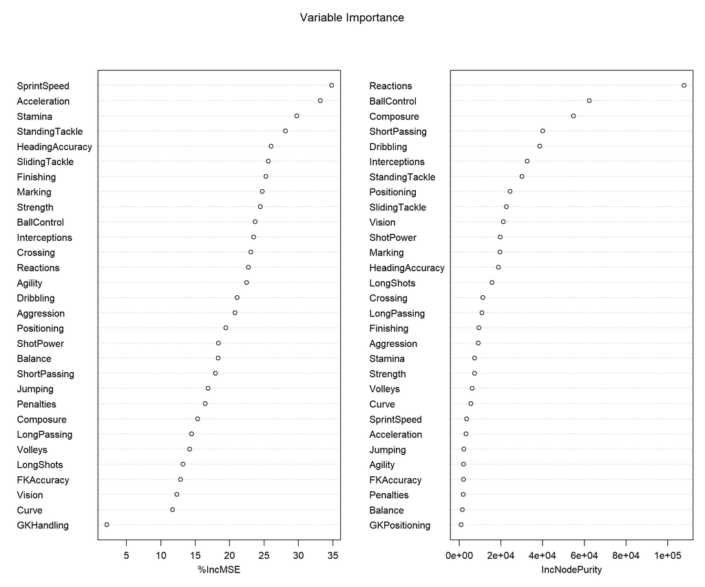

```r
# display variable importance
varImpPlot(rf_Overall_reg2, main = "Variable Importance")
```

# Conclusion - RF Classification and Regression Models

In conclusion, randomForest for classification for players’ International Reputation based on players’ skill ratings in the 2019 FIFA player data set performed poorly due to extremely skewed distribution of players’ rank. For similar reasons, the classification model to predict players’ positions based on skill ratings did not perform well either.

# Part II - Multinomial Logistic Regression

… continue in next file …